# MIMIC 心电图 AI 诊断标签噪声分析

基于 MIMIC 合并-8.11（1000 例专家审阅）的重复性、标签准确性及三库（MIMIC / 宁波 / PTB-XL）对照研究

Author

数据分析组

Published

August 11, 2026

**展开代码**

```r
set.seed(20260717)
knitr::opts_chunk$set(
  warning = FALSE, message = FALSE,
  dev = "ragg_png", dpi = 300, fig.align = "center", out.width = "100%"
)
suppressPackageStartupMessages({
  library(tidyverse); library(readxl); library(gt); library(scales)
  library(jsonlite); library(patchwork)
})

# ---- 中文字体（ragg 设备 + PingFang SC）----
FONT <- "PingFang SC"
theme_set(
  theme_minimal(base_family = FONT) +
    theme(
      plot.title    = element_text(face = "bold", size = 14, family = FONT),
      plot.subtitle = element_text(size = 10.5, color = "#555555", family = FONT),
      plot.caption  = element_text(size = 8.5, color = "#777777", family = FONT,
                                   hjust = 0, margin = margin(t = 6)),
      strip.text    = element_text(face = "bold", family = FONT),
      axis.text     = element_text(family = FONT)
    )
)

# ---- 色盲友好配色（Okabe-Ito）----
C_OK  <- "#009E73"; C_BAD <- "#D55E00"; C_MID <- "#E69F00"
C_BLU <- "#0072B2"; C_SKY <- "#56B4E9"; C_PNK <- "#CC79A7"; C_GRY <- "#999999"

# ---- 中英 ECG 诊断术语互译映射（图内数据标签双语化用）----
zh2en <- c(
  "窦性心律" = "Sinus rhythm",
  "窦性心动过速" = "Sinus tachycardia",
  "窦性心动过缓" = "Sinus bradycardia",
  "窦性心律不齐" = "Sinus arrhythmia",
  "窦性停搏" = "Sinus arrest",
  "窦房结游走心律" = "Wandering atrial pacemaker",
  "电轴左偏" = "Left axis deviation",
  "电轴右偏" = "Right axis deviation",
  "电轴显著左偏" = "Marked left axis deviation",
  "电轴偏" = "Axis deviation",
  "心电轴正常" = "Normal axis",
  "心电轴左偏" = "Left axis deviation",
  "心电轴偏" = "Axis deviation",
  "为正常变异" = "Normal variant",
  "由心肌缺血所致" = "Due to myocardial ischemia",
  "由心肌缺血" = "Due to myocardial ischemia",
  "由心肌缺血所至" = "Due to myocardial ischemia",
  "QT 间期延长" = "Prolonged QT interval",
  "QT间期延长" = "Prolonged QT interval",
  "QT间期缩短" = "Short QT interval",
  "下壁心肌梗死" = "Inferior myocardial infarction",
  "下壁" = "Inferior",
  "下壁心梗" = "Inferior MI",
  "急性下壁心肌梗死" = "Acute inferior MI",
  "前壁心肌梗死" = "Anterior myocardial infarction",
  "前壁" = "Anterior",
  "侧壁心肌梗死" = "Lateral myocardial infarction",
  "侧壁" = "Lateral",
  "侧壁ST-T改变" = "Lateral ST-T changes",
  "ST-T改变" = "ST-T changes",
  "T波改变" = "T wave changes",
  "ST段压低" = "ST segment depression",
  "ST段抬高" = "ST segment elevation",
  "左心室肥厚" = "Left ventricular hypertrophy",
  "右心室肥厚" = "Right ventricular hypertrophy",
  "左房肥大" = "Left atrial enlargement",
  "右房肥大" = "Right atrial enlargement",
  "左束支传导阻滞" = "Left bundle branch block",
  "完全性左束支传导阻滞" = "Complete left bundle branch block",
  "右束支传导阻滞" = "Right bundle branch block",
  "完全性右束支传导阻滞" = "Complete right bundle branch block",
  "心室内传导阻滞" = "Intraventricular conduction delay",
  "一度房室传导阻滞" = "First-degree AV block",
  "二度房室传导阻滞" = "Second-degree AV block",
  "三度房室传导阻滞" = "Third-degree AV block",
  "房性早搏" = "Premature atrial complexes",
  "室性早搏" = "Premature ventricular complexes",
  "室上性早搏" = "Premature supraventricular complexes",
  "房性心动过速" = "Atrial tachycardia",
  "室性心动过速" = "Ventricular tachycardia",
  "心房颤动" = "Atrial fibrillation",
  "心房扑动" = "Atrial flutter",
  "心室颤动" = "Ventricular fibrillation",
  "R波递增不良" = "Poor R wave progression",
  "R 波递增不良" = "Poor R wave progression",
  "心电图异常" = "Abnormal ECG",
  "临界心电图" = "Borderline ECG",
  "正常心电图" = "Normal ECG",
  "正常 ECG" = "Normal ECG",
  "正常范围心电图" = "ECG within normal limits",
  "大致正常心电图" = "Essentially normal ECG",
  "心房起搏" = "Atrial paced rhythm",
  "心室起搏" = "Ventricular paced rhythm",
  "起搏心律" = "Paced rhythm",
  "胸导联低电压" = "Low precordial voltage",
  "肢体导联低电压" = "Low limb lead voltage",
  "低电压" = "Low voltage",
  "右心室" = "Right ventricle",
  "左心室" = "Left ventricle",
  "Brugada波" = "Brugada pattern",
  "Brugada 样改变" = "Brugada-like pattern",
  "早期复极" = "Early repolarization",
  "心室预激" = "Ventricular preexcitation",
  "预激综合征" = "Pre-excitation syndrome",
  "WPW综合征" = "WPW syndrome",
  "尖端扭转" = "Torsades de pointes",
  "时期未定" = "Undetermined timing",
  "异常" = "Abnormal",
  "正常" = "Normal",
  "交界性心律" = "Junctional rhythm",
  "加速性交界性心律" = "Accelerated junctional rhythm"
)
en2zh <- c(
  "Sinus rhythm" = "窦性心律",
  "Sinus tachycardia" = "窦性心动过速",
  "Sinus bradycardia" = "窦性心动过缓",
  "Sinus arrhythmia" = "窦性心律不齐",
  "Abnormal ECG" = "心电图异常",
  "Borderline ECG" = "临界心电图",
  "Normal ECG" = "正常 ECG",
  "Normal ECG except for rate" = "正常 ECG（除外心率）",
  "Sinus rhythm." = "窦性心律（伴...",
  "Left axis deviation" = "电轴左偏",
  "Prolonged QT interval" = "QT 间期延长",
  "Inferior T wave changes are nonspecific" = "下壁 T 波改变（非特异性）",
  "Low QRS voltages in precordial leads" = "胸导联 QRS 低电压",
  "Leftward axis" = "电轴左偏",
  "Possible anterior infarct - age undetermined" = "可能前壁梗死（年龄未定）",
  "Poor R wave progression - probable normal variant" = "R 波递增不良（可能正常变异）",
  "rSr(V1) - probable normal variant" = "rSr(V1)（可能正常变异）",
  "Left bundle branch block" = "左束支传导阻滞",
  "Possible inferior infarct - age undetermined" = "可能下壁梗死（年龄未定）",
  "Inferior infarct - age undetermined" = "下壁梗死（年龄未定）",
  "Left ventricular hypertrophy" = "左心室肥厚",
  "Normal sinus rhythm" = "正常窦性心律",
  "Atrial fibrillation" = "心房颤动",
  "Atrial flutter" = "心房扑动",
  "Ventricular tachycardia" = "室性心动过速",
  "Premature ventricular complexes" = "室性早搏",
  "Premature atrial complexes" = "房性早搏",
  "Right bundle branch block" = "右束支传导阻滞",
  "First-degree AV block" = "一度房室传导阻滞",
  "Inferior MI" = "下壁心梗",
  "Anterior MI" = "前壁心梗",
  "Lateral MI" = "侧壁心梗",
  "Marked left axis deviation" = "电轴显著左偏",
  "Right axis deviation" = "电轴右偏",
  "ST segment depression" = "ST 段压低",
  "ST segment elevation" = "ST 段抬高",
  "T wave inversion" = "T 波倒置",
  "T wave abnormality" = "T 波异常",
  "Nonspecific ST and T wave abnormalities" = "非特异性 ST-T 异常",
  "Low QRS voltage" = "QRS 低电压",
  "Poor R wave progression" = "R 波递增不良",
  "Paced rhythm" = "起搏心律",
  "Ectopic atrial rhythm" = "异位房性心律"
)

# ---- 统计辅助 ----
fpct <- function(x, d = 1) ifelse(is.na(x), "不适用", percent(x, accuracy = 0.1))
gt_std <- function(x, fsize = 12) {
  x |>
    tab_options(table.width = pct(100), table.font.size = px(fsize),
                heading.align = "left") |>
    tab_style(style = cell_text(weight = "bold"), locations = cells_column_labels())
}
```

**展开代码**

```r
J <- fromJSON("mimic_analysis.json")

# 重复性
dedup_findings <- J$dedup$findings
report_top     <- J$dedup$detail_tables$report_top_repeats
dedup_concl    <- J$dedup$conclusion
dedup_rec      <- J$dedup$recommendation

# 统计
lab    <- J$stats$label
demo   <- J$stats$demo
age_b  <- J$stats$age_bands
top_zh <- J$stats$top_zh_terms
top_en <- J$stats$top_en_terms
term_acc <- J$stats$term_accuracy
inacc  <- J$stats$inaccuracy_nature
redund <- J$stats$label_redundancy

# 三库对照
overview  <- J$compare$overview
label_cmp <- J$compare$label_cmp$rows
demo_cmp  <- J$compare$demo_cmp$rows
sampling_note <- J$compare$sampling_note
vocab    <- J$compare$vocab
vocab_note <- J$compare$vocab_note

# 派生：三库主集不准确率 / 准确率
cmp_rate <- label_cmp |>
  mutate(不准确率 = `不准确率%(主集)`,
         准确率   = 100 - `不准确率%(主集)`)
```

# 1 摘要

## 研究概要

**重复性：**经全字段、annotation_id、id、subject_id、study_id 五类关键字段核查，**不存在真实重复记录**；report/report_cn 文本重复源于自由文本 ECG 标签的天然集中度（如「Sinus rhythm, Normal ECG」出现 181 次），属抽样样本的真实分布特征，**不应去重**。

**标签准确性：**准确 **226 例 (22.6%)**、不准确 **774 例 (77.4%)**、未判定 0 例 (0.0%)；主分析集（全量 n=1000，无未判定）不准确率 **77.4%**，高于宁波（55.3%）与 PTB-XL（57.5%）。专家纠正标签填写率 100%。错误性质以**遗漏型**为主（38.6% 的不准确案例纠正后术语更多）。

# 2 数据与方法

## 2.1 数据来源

本分析对象为专家评审后的 MIMIC 数据 `MIMIC 合并-8.11.xlsx`，共 **1000 行 × 13 列**，字段含 `subject_id / study_id / annotation_id / id / report(英文自由文本) / report_cn(专家中文翻译) / correctLabel(专家纠正标签) / conclusionChoice(准确/不准确/未判定) / annotator / anchor_age / gender / anchor_year / created_at`。所有分析由 `analyze_mimic.py` 完成并导出为 `mimic_analysis.json`，本报告图表与表格均由其驱动，保证与独立交付的 HTML 模拟器口径一致。

## 2.2 三库概况对照

**展开代码**

```r
overview |>
  gt() |> gt_std() |>
  cols_label(
    库 = "数据库", 行数 = "样本量(行)", 主键 = "主键",
    抽样方法 = "抽样方法", 人群 = "目标人群", 诊断命名 = "诊断命名体系"
  ) |>
  tab_header("表 1. 三库基本概况对照")
```

Table 1

表 1. 三库基本概况对照

| 数据库 | 样本量(行) | 主键 | 抽样方法 | 目标人群 | 诊断命名体系 |
| --- | --- | --- | --- | --- | --- |
| MIMIC (本分析) | 1000 | annotation_id | 简单随机抽样(自 MIMIC 原始库) | ICU 住院患者(MIMIC-IV) | 英文自由文本 + 专家中文翻译(report_cn) |
| 宁波(去重主集) | 623 | record_id | 医院连续收录 + 分层抽样字段 | 单中心门诊/住院心电图 | 中文结构化(combo_pattern/diagnose_chinese_names) |
| PTB-XL | 674 | number | 公开库按年龄/性别/报告比例分层 | 多中心门诊心电图 | SCP 编码(SCP_en_cn) |

**展开代码**

```r
overview |>
  gt() |> gt_std() |>
  cols_label(
    库 = "Database", 行数 = "Sample size (rows)", 主键 = "Primary key",
    抽样方法 = "Sampling method", 人群 = "Target population", 诊断命名 = "Nomenclature"
  ) |>
  tab_header("Table 1. Basic overview of the three databases")
```

Table 2

Table 1. Basic overview of the three databases

| Database | Sample size (rows) | Primary key | Sampling method | Target population | Nomenclature |
| --- | --- | --- | --- | --- | --- |
| MIMIC (本分析) | 1000 | annotation_id | 简单随机抽样(自 MIMIC 原始库) | ICU 住院患者(MIMIC-IV) | 英文自由文本 + 专家中文翻译(report_cn) |
| 宁波(去重主集) | 623 | record_id | 医院连续收录 + 分层抽样字段 | 单中心门诊/住院心电图 | 中文结构化(combo_pattern/diagnose_chinese_names) |
| PTB-XL | 674 | number | 公开库按年龄/性别/报告比例分层 | 多中心门诊心电图 | SCP 编码(SCP_en_cn) |

MIMIC 与另两库的核心差异在于**抽样框架与命名体系**：MIMIC 源自 ICU 住院队列且采用简单随机抽样 + 英文自由文本标签；宁波、PTB-XL 分别为单中心门诊/多中心门诊、分层抽样 + 结构化（中文 / SCP 编码）标签。这一差异是后续三库标签准确性不可直接比较的根本原因。

## 2.3 抽样方法对代表性的影响（方法学评估）

MIMIC 采用简单随机抽样(simple random sampling)自 MIMIC-IV 原始库。其代表性需从两层理解：  
① 对 MIMIC-IV 总体(ICU 住院人群)：若抽样框完整且随机，则对本队列内部推断有效；  
② 对「真实世界 ECG 标签准确性」外部推断：代表性有限——MIMIC 仅覆盖 ICU 住院患者，其诊断组合(更多急性/危重心律、更多起搏/缺血)与门诊 ECG 库(宁波/PTB-XL)存在选择偏倚；且 MIMIC 原始诊断命名空间极复杂(自由文本 + ICD/MEOW 等)，简单随机抽样未能按诊断类分层抽样，故稀有诊断(如 Brugada、预激、尖端扭转型室速)在 1000 例样本中被低估，其标签错误率估计的置信区间将偏宽。建议：若需推断门诊 ECG 总体，应改用分层抽样；若仅描述 ICU ECG 标签质量，当前抽样可接受，但需显式声明人群边界。

# 3 数据重复性检查

## 3.1 七类核查结论

**展开代码**

```r
dedup_findings |>
  mutate(
    冗余簇数 = clusters, 冗余行数 = extra_rows,
    across(c(conf, clusters, extra_rows), as.character)
  ) |>
  gt() |> gt_std(fsize = 11) |>
  cols_label(
    key = "核查维度", rule = "判定规则", conf = "置信度",
    冗余簇数 = "冗余簇数", 冗余行数 = "冗余行数", note = "说明"
  ) |>
  tab_header("表 2. MIMIC 数据重复性七类核查") |>
  fmt_markdown(columns = note)
```

Table 3

表 2. MIMIC 数据重复性七类核查

| 核查维度 | 判定规则 | 置信度 | clusters | extra_rows | 说明 | 冗余簇数 | 冗余行数 |
| --- | --- | --- | --- | --- | --- | --- | --- |
| 全字段完全重复 | 13 列全部相同 | 高 | 0 | 0 | 未发现整行完全重复。 | 0 | 0 |
| annotation_id 重复 | 标注平台唯一标注ID相同 | 高 | 0 | 0 | annotation_id 全部唯一，无重复。 | 0 | 0 |
| id 重复 | 顺序ID相同 | 高 | 0 | 0 | id 全部唯一。 | 0 | 0 |
| report 英文文本重复(诊断集中度) | 英文 ECG 描述完全相同 | 中（需结合 subject_id 判断） | 75 | 419 | ⚠ 但 1000 行的 subject_id 全部唯一，说明这些「相同文本」来自【不同患者】共享的常见 ECG 结论（如 ‘Sinus rhythm,Normal ECG’ 出现 181 次）。对自由文本标签而言属正常现象，【不是重复记录，不应去重】；它反映的是 MIMIC 诊断文本的高度集中。 | 75 | 419 |
| report_cn 中文文本重复(诊断集中度) | 中文 ECG 描述完全相同 | 中（需结合 subject_id 判断） | 74 | 424 | 与 report 英文重复同源：同一中文结论（如「窦性心律，正常心电图」）跨不同患者重复出现，非记录级重复。 | 74 | 424 |
| subject_id+study_id 重复 | 同患者同次住院出现≥2条 | 中（同次住院多份心电图或重复导出） | 0 | 0 | 无同患者同次住院重复。 | 0 | 0 |
| subject_id 重复（基线） | 同一 MIMIC 患者(subject_id)出现多条 | 信息项 | 0 | 0 | MIMIC 为 ICU 队列，同患者多次心电图属正常；本样本 1000 行 subject_id 全部唯一，即 1000 例来自 1000 名不同患者，不存在患者级冗余。 | 0 | 0 |

**展开代码**

```r
dedup_findings |>
  mutate(
    冗余簇数 = clusters, 冗余行数 = extra_rows,
    across(c(conf, clusters, extra_rows), as.character)
  ) |>
  gt() |> gt_std(fsize = 11) |>
  cols_label(
    key = "Check dimension", rule = "Decision rule", conf = "Confidence",
    冗余簇数 = "Redundant clusters", 冗余行数 = "Redundant rows", note = "Note"
  ) |>
  tab_header("Table 2. Seven-dimension duplication check of MIMIC data") |>
  fmt_markdown(columns = note)
```

Table 4

Table 2. Seven-dimension duplication check of MIMIC data

| Check dimension | Decision rule | Confidence | clusters | extra_rows | Note | Redundant clusters | Redundant rows |
| --- | --- | --- | --- | --- | --- | --- | --- |
| 全字段完全重复 | 13 列全部相同 | 高 | 0 | 0 | 未发现整行完全重复。 | 0 | 0 |
| annotation_id 重复 | 标注平台唯一标注ID相同 | 高 | 0 | 0 | annotation_id 全部唯一，无重复。 | 0 | 0 |
| id 重复 | 顺序ID相同 | 高 | 0 | 0 | id 全部唯一。 | 0 | 0 |
| report 英文文本重复(诊断集中度) | 英文 ECG 描述完全相同 | 中（需结合 subject_id 判断） | 75 | 419 | ⚠ 但 1000 行的 subject_id 全部唯一，说明这些「相同文本」来自【不同患者】共享的常见 ECG 结论（如 ‘Sinus rhythm,Normal ECG’ 出现 181 次）。对自由文本标签而言属正常现象，【不是重复记录，不应去重】；它反映的是 MIMIC 诊断文本的高度集中。 | 75 | 419 |
| report_cn 中文文本重复(诊断集中度) | 中文 ECG 描述完全相同 | 中（需结合 subject_id 判断） | 74 | 424 | 与 report 英文重复同源：同一中文结论（如「窦性心律，正常心电图」）跨不同患者重复出现，非记录级重复。 | 74 | 424 |
| subject_id+study_id 重复 | 同患者同次住院出现≥2条 | 中（同次住院多份心电图或重复导出） | 0 | 0 | 无同患者同次住院重复。 | 0 | 0 |
| subject_id 重复（基线） | 同一 MIMIC 患者(subject_id)出现多条 | 信息项 | 0 | 0 | MIMIC 为 ICU 队列，同患者多次心电图属正常；本样本 1000 行 subject_id 全部唯一，即 1000 例来自 1000 名不同患者，不存在患者级冗余。 | 0 | 0 |

## 3.2 诊断文本集中度（非重复记录）

report 英文文本重复 Top 条目显示，少数高频诊断主导标签空间：

**展开代码**

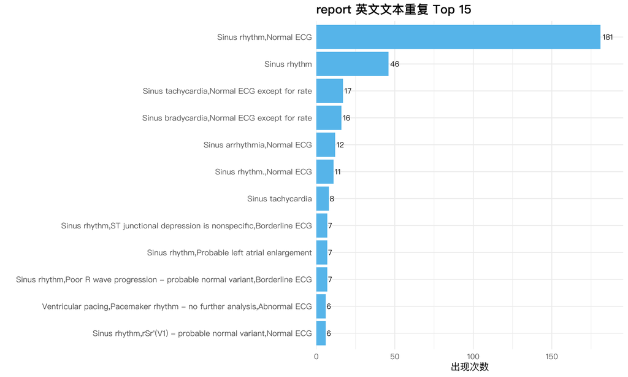

```r
rt <- report_top |> slice_head(n = 15) |> mutate(report = fct_reorder(report, n))
ggplot(rt, aes(x = n, y = report)) +
  geom_col(fill = C_SKY) +
  geom_text(aes(label = n), hjust = -0.2, size = 3, family = FONT) +
  labs(title = "report 英文文本重复 Top 15", x = "出现次数", y = "") +
  scale_x_continuous(expand = expansion(mult = c(0, 0.08))) +
  theme(axis.text.y = element_text(size = 9))
```

**展开代码**

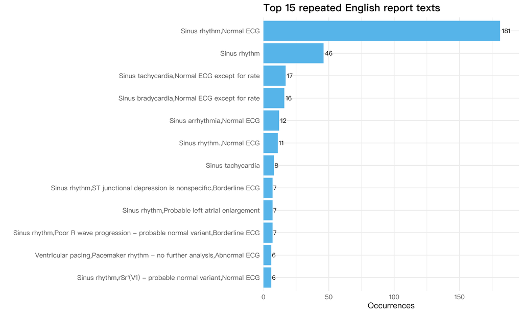

```r
rt <- report_top |> slice_head(n = 15) |> mutate(report = fct_reorder(report, n))
ggplot(rt, aes(x = n, y = report)) +
  geom_col(fill = C_SKY) +
  geom_text(aes(label = n), hjust = -0.2, size = 3, family = FONT) +
  labs(title = "Top 15 repeated English report texts", x = "Occurrences", y = "") +
  scale_x_continuous(expand = expansion(mult = c(0, 0.08))) +
  theme(axis.text.y = element_text(size = 9))
```

## 3.3 结论与处理建议

**结论：** 经全字段、annotation_id、id、subject_id、study_id 五类关键字段核查，MIMIC 合并-8.11 的 1000 行记录【不存在真实的重复记录】（所有强重复信号字段均唯一）。report/report_cn 的「文本重复」源于自由文本 ECG 标签的天然集中度（常见结论如窦性心律/正常心电图跨患者大量重复），属抽样样本的真实诊断分布特征，而非导出缺陷，【不应作为重复剔除】。因此本分析直接以全量 1000 例作为 MIMIC 主分析集，主键采用 annotation_id。

**处理建议：** ① 无需对 MIMIC 做记录级去重（关键ID全唯一）；② 若后续与其他库合并做患者级分析，应以 subject_id 聚类并报告跨患者稳健性；③ report 文本高重复度提示：简单随机抽样下，少数高频诊断主导了标签空间，稀有诊断(如 Brugada/预激/尖端扭转)在 1000 例中被严重低估，建议补充按诊断分层抽样以校准罕见诊断的错误率估计。

本报告以**全量 1000 例**作为 MIMIC 主分析集（主键 `annotation_id`），不做记录级去重。

# 4 标签准确性分析

## 4.1 总体准确性与置信区间

**展开代码**

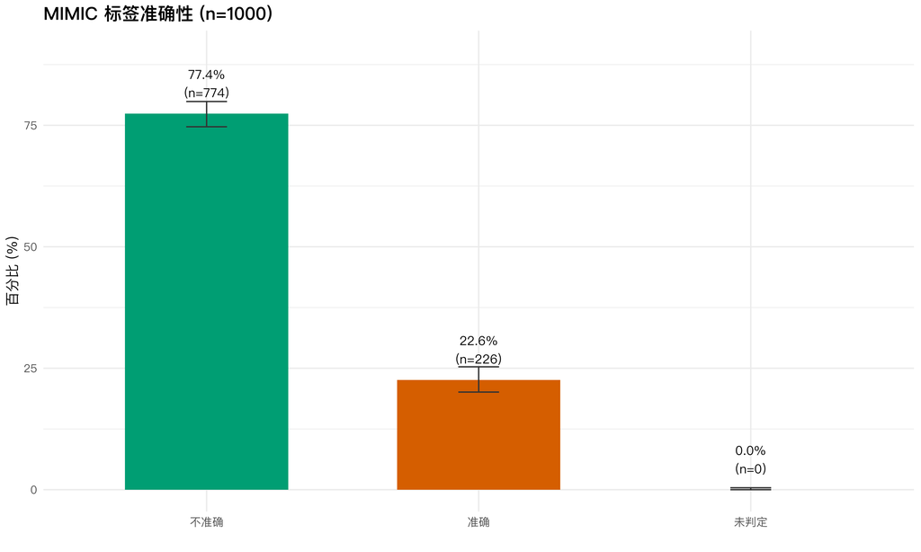

Figure 3: 图 2. MIMIC 标签准确性分布（含 Wilson 95% 置信区间）

```r
lab_df <- tibble(
  cat = c("准确", "不准确", "未判定"),
  n   = c(lab$acc, lab$ina, lab$und),
  p   = c(lab$acc_p, lab$ina_p, lab$und_p),
  lo  = c(lab$acc_ci[1], lab$ina_ci[1], lab$und_ci[1]),
  hi  = c(lab$acc_ci[2], lab$ina_ci[2], lab$und_ci[2])
)
ggplot(lab_df, aes(x = cat, y = p, fill = cat)) +
  geom_col(width = 0.6) +
  geom_errorbar(aes(ymin = lo, ymax = hi), width = 0.15, color = "#333") +
  geom_text(aes(label = sprintf("%.1f%%\n(n=%d)", p, n)), vjust = -0.6, size = 3.5, family = FONT) +
  scale_fill_manual(values = c(C_OK, C_BAD, C_GRY)) +
  labs(title = "MIMIC 标签准确性 (n=1000)", x = "", y = "百分比 (%)") +
  ylim(0, 90) +
  theme(legend.position = "none")
```

**展开代码**

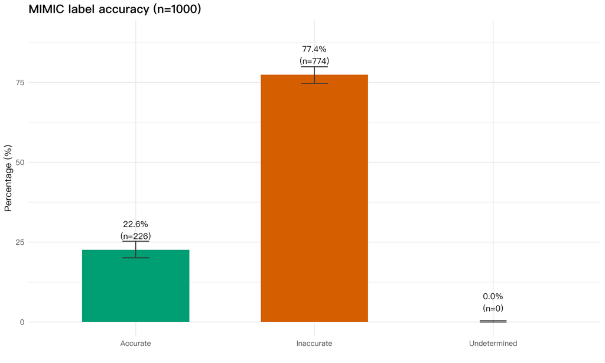

Figure 4: Figure 2. MIMIC label accuracy distribution (with Wilson 95% CI)

```r
lab_df <- tibble(
  cat = c("Accurate", "Inaccurate", "Undetermined"),
  n   = c(lab$acc, lab$ina, lab$und),
  p   = c(lab$acc_p, lab$ina_p, lab$und_p),
  lo  = c(lab$acc_ci[1], lab$ina_ci[1], lab$und_ci[1]),
  hi  = c(lab$acc_ci[2], lab$ina_ci[2], lab$und_ci[2])
)
ggplot(lab_df, aes(x = cat, y = p, fill = cat)) +
  geom_col(width = 0.6) +
  geom_errorbar(aes(ymin = lo, ymax = hi), width = 0.15, color = "#333") +
  geom_text(aes(label = sprintf("%.1f%%\n(n=%d)", p, n)), vjust = -0.6, size = 3.5, family = FONT) +
  scale_fill_manual(values = c(C_OK, C_BAD, C_GRY)) +
  labs(title = "MIMIC label accuracy (n=1000)", x = "", y = "Percentage (%)") +
  ylim(0, 90) +
  theme(legend.position = "none")
```

**展开代码**

```r
tibble(
  判定 = c("准确", "不准确", "未判定", "合计"),
  例数 = c(lab$acc, lab$ina, lab$und, lab$acc + lab$ina + lab$und),
  百分比 = c(lab$acc_p, lab$ina_p, lab$und_p, 100.0),
  `95% CI` = c(
    sprintf("%.1f–%.1f%%", lab$acc_ci[1], lab$acc_ci[2]),
    sprintf("%.1f–%.1f%%", lab$ina_ci[1], lab$ina_ci[2]),
    sprintf("%.1f–%.1f%%", lab$und_ci[1], lab$und_ci[2]),
    "—"
  )
) |>
  gt() |> gt_std() |>
  tab_header("表 3. MIMIC 标签准确性与 Wilson 95% 置信区间")
```

Table 5

表 3. MIMIC 标签准确性与 Wilson 95% 置信区间

| 判定 | 例数 | 百分比 | 95% CI |
| --- | --- | --- | --- |
| 准确 | 226 | 22.6 | 20.1–25.3% |
| 不准确 | 774 | 77.4 | 74.7–79.9% |
| 未判定 | 0 | 0.0 | 0.0–0.4% |
| 合计 | 1000 | 100.0 | — |

**展开代码**

```r
tibble(
  Verdict = c("Accurate", "Inaccurate", "Undetermined", "Total"),
  Cases = c(lab$acc, lab$ina, lab$und, lab$acc + lab$ina + lab$und),
  Percentage = c(lab$acc_p, lab$ina_p, lab$und_p, 100.0),
  `95% CI` = c(
    sprintf("%.1f–%.1f%%", lab$acc_ci[1], lab$acc_ci[2]),
    sprintf("%.1f–%.1f%%", lab$ina_ci[1], lab$ina_ci[2]),
    sprintf("%.1f–%.1f%%", lab$und_ci[1], lab$und_ci[2]),
    "—"
  )
) |>
  gt() |> gt_std() |>
  tab_header("Table 3. MIMIC label accuracy and Wilson 95% CI")
```

Table 6

Table 3. MIMIC label accuracy and Wilson 95% CI

| Verdict | Cases | Percentage | 95% CI |
| --- | --- | --- | --- |
| Accurate | 226 | 22.6 | 20.1–25.3% |
| Inaccurate | 774 | 77.4 | 74.7–79.9% |
| Undetermined | 0 | 0.0 | 0.0–0.4% |
| Total | 1000 | 100.0 | — |

专家纠正标签（`correctLabel`）填写率 **100.0%**，填补了 MIMIC 原始库仅有英文诊断、缺少结构化纠正标签的缺陷，是后续跨库中文对照的基础。

## 4.2 错误性质：遗漏型 vs 误判型

**展开代码**

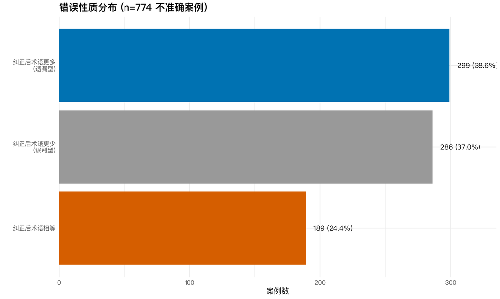

Figure 5: 图 3. 不准确案例的错误性质（原始标签术语数 vs 专家纠正标签术语数）

```r
nature <- tibble(
  类别 = c("纠正后术语更多\n(遗漏型)", "纠正后术语相等", "纠正后术语更少\n(误判型)"),
  n = c(inacc$corr_gt_orig, inacc$corr_eq_orig, inacc$corr_lt_orig)
) |> mutate(类别 = fct_reorder(类别, n))
ggplot(nature, aes(x = n, y = 类别, fill = 类别)) +
  geom_col() +
  geom_text(aes(label = sprintf("%d (%.1f%%)", n, n / inacc$n * 100)),
            hjust = -0.2, size = 3.5, family = FONT) +
  scale_fill_manual(values = c(C_BAD, C_GRY, C_BLU)) +
  labs(title = sprintf("错误性质分布 (n=%d 不准确案例)", inacc$n), x = "案例数", y = "") +
  scale_x_continuous(expand = expansion(mult = c(0, 0.12))) +
  theme(legend.position = "none")
```

**展开代码**

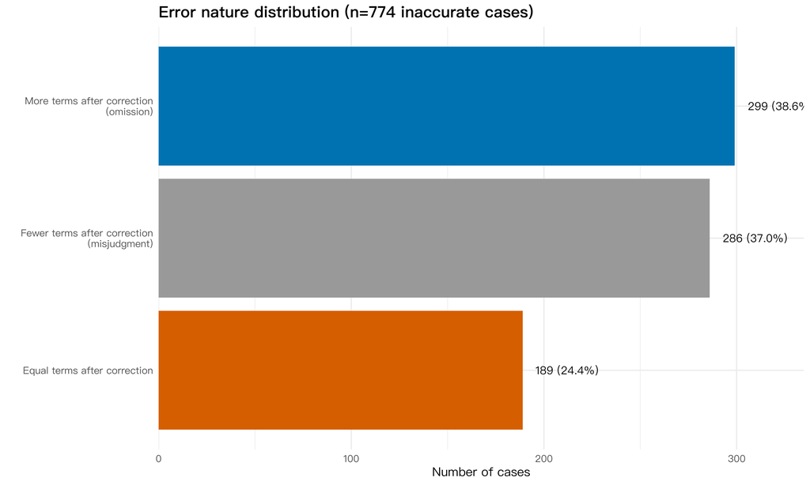

Figure 6: Figure 3. Nature of errors in inaccurate cases (original vs expert-corrected term counts)

```r
nature <- tibble(
  cat = c("More terms after correction\n(omission)", "Equal terms after correction", "Fewer terms after correction\n(misjudgment)"),
  n = c(inacc$corr_gt_orig, inacc$corr_eq_orig, inacc$corr_lt_orig)
) |> mutate(cat = fct_reorder(cat, n))
ggplot(nature, aes(x = n, y = cat, fill = cat)) +
  geom_col() +
  geom_text(aes(label = sprintf("%d (%.1f%%)", n, n / inacc$n * 100)),
            hjust = -0.2, size = 3.5, family = FONT) +
  scale_fill_manual(values = c(C_BAD, C_GRY, C_BLU)) +
  labs(title = sprintf("Error nature distribution (n=%d inaccurate cases)", inacc$n), x = "Number of cases", y = "") +
  scale_x_continuous(expand = expansion(mult = c(0, 0.12))) +
  theme(legend.position = "none")
```

# 5 诊断分布

## 5.1 中文诊断词频 Top 20

**展开代码**

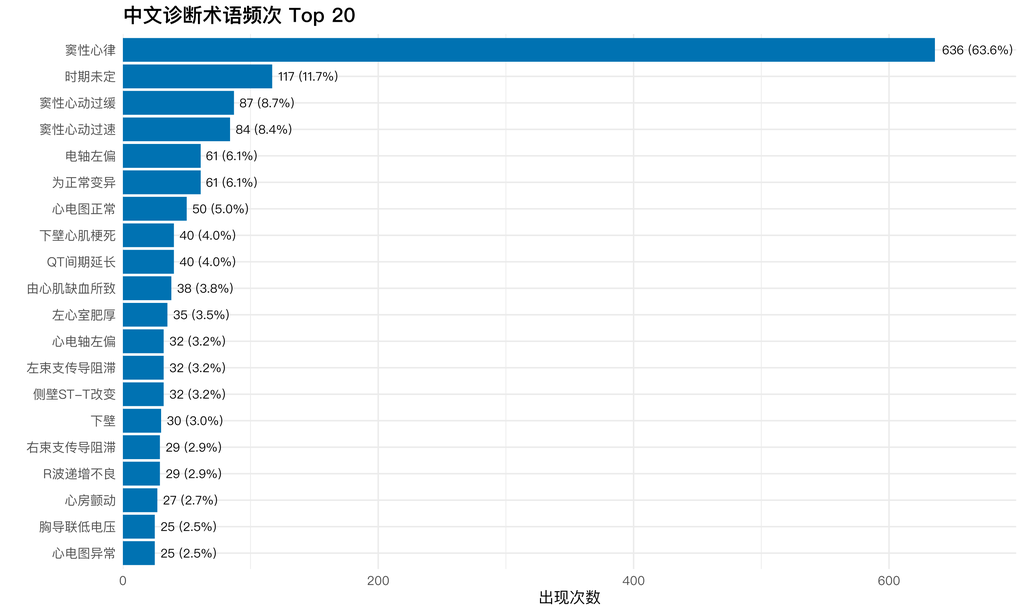

Figure 7: 图 4. MIMIC 中文诊断术语频次 Top 20（基于 report_cn）

```r
tz <- top_zh |> slice_head(n = 20) |> mutate(term = fct_reorder(term, n))
ggplot(tz, aes(x = n, y = term, fill = n)) +
  geom_col(fill = C_BLU) +
  geom_text(aes(label = sprintf("%d (%.1f%%)", n, p)), hjust = -0.1, size = 3, family = FONT) +
  scale_fill_gradient(low = C_SKY, high = C_BLU) +
  labs(title = "中文诊断术语频次 Top 20", x = "出现次数", y = "") +
  scale_x_continuous(expand = expansion(mult = c(0, 0.1))) +
  theme(axis.text.y = element_text(size = 9), legend.position = "none")
```

**展开代码**

[figure not shown]

Figure 8: Figure 4. Top 20 Chinese diagnosis term frequencies (English labels, based on report_cn)

```r
tz <- top_zh |> slice_head(n = 20) |>
  mutate(term_en = ifelse(term %in% names(zh2en), zh2en[term], term)) |>
  mutate(term_en = fct_reorder(term_en, n))
ggplot(tz, aes(x = n, y = term_en, fill = n)) +
  geom_col(fill = C_BLU) +
  geom_text(aes(label = sprintf("%d (%.1f%%)", n, p)), hjust = -0.1, size = 3, family = FONT) +
  scale_fill_gradient(low = C_SKY, high = C_BLU) +
  labs(title = "Top 20 Chinese diagnosis term frequencies (English labels)", x = "Occurrences", y = "") +
  scale_x_continuous(expand = expansion(mult = c(0, 0.1))) +
  theme(axis.text.y = element_text(size = 9), legend.position = "none")
```

## 5.2 英文诊断词频 Top 20

**展开代码**

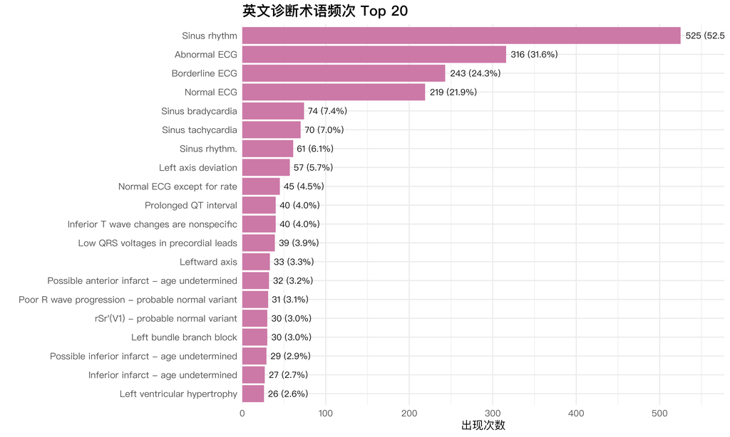

Figure 9: 图 5. MIMIC 英文诊断术语频次 Top 20（基于 report）

```r
te <- top_en |> slice_head(n = 20) |> mutate(term = fct_reorder(term, n))
ggplot(te, aes(x = n, y = term, fill = n)) +
  geom_col(fill = C_PNK) +
  geom_text(aes(label = sprintf("%d (%.1f%%)", n, p)), hjust = -0.1, size = 3, family = FONT) +
  scale_fill_gradient(low = "#E8B7D4", high = C_PNK) +
  labs(title = "英文诊断术语频次 Top 20", x = "出现次数", y = "") +
  scale_x_continuous(expand = expansion(mult = c(0, 0.1))) +
  theme(axis.text.y = element_text(size = 9), legend.position = "none")
```

**展开代码**

[figure not shown]

Figure 10: 图 5. MIMIC 英文诊断术语频次 Top 20（中文标签，基于 report）

```r
te <- top_en |> slice_head(n = 20) |>
  mutate(term_zh = ifelse(term %in% names(en2zh), en2zh[term], term)) |>
  mutate(term_zh = fct_reorder(term_zh, n))
ggplot(te, aes(x = n, y = term_zh, fill = n)) +
  geom_col(fill = C_PNK) +
  geom_text(aes(label = sprintf("%d (%.1f%%)", n, p)), hjust = -0.1, size = 3, family = FONT) +
  scale_fill_gradient(low = "#E8B7D4", high = C_PNK) +
  labs(title = "英文诊断术语频次 Top 20（中文标签）", x = "出现次数", y = "") +
  scale_x_continuous(expand = expansion(mult = c(0, 0.1))) +
  theme(axis.text.y = element_text(size = 9), legend.position = "none")
```

## 5.3 术语级准确性（Top 20 高频术语）

**展开代码**

```r
ta <- term_acc |> slice_head(n = 20) |>
  mutate(term = fct_reorder(term, ina), tot = acc + ina) |>
  pivot_longer(c(acc, ina), names_to = "判定", values_to = "cnt") |>
  mutate(判定 = factor(判定, levels = c("acc", "ina"),
                       labels = c("准确", "不准确")),
         pct = cnt / tot * 100)
ggplot(ta, aes(x = term, y = cnt, fill = 判定)) +
  geom_col(position = "dodge", width = 0.7) +
  geom_text(aes(label = sprintf("%d (%.1f%%)", cnt, pct)),
            position = position_dodge(width = 0.7),
            hjust = -0.25, size = 3.2, family = FONT, color = "#1a1a1a") +
  coord_flip() +
  scale_fill_manual(values = c(C_OK, C_BAD)) +
  scale_y_continuous(expand = expansion(mult = c(0, 0.4))) +
  labs(title = "Top 20 高频术语的准确 vs 不准确例数", x = "", y = "例数") +
  theme(axis.text.y = element_text(size = 8),
        axis.text.x = element_text(size = 9),
        legend.position = "top")
```

[figure not shown]

Figure 11: 图 6. Top 20 高频术语的准确/不准确例数（红=不准确，绿=准确）

**展开代码**

```r
ta <- term_acc |> slice_head(n = 20) |>
  mutate(term_en = ifelse(term %in% names(zh2en), zh2en[term], term)) |>
  mutate(term_en = fct_reorder(term_en, ina), tot = acc + ina) |>
  pivot_longer(c(acc, ina), names_to = "Verdict", values_to = "cnt") |>
  mutate(Verdict = factor(Verdict, levels = c("acc", "ina"),
                       labels = c("Accurate", "Inaccurate")),
         pct = cnt / tot * 100)
ggplot(ta, aes(x = term_en, y = cnt, fill = Verdict)) +
  geom_col(position = "dodge", width = 0.7) +
  geom_text(aes(label = sprintf("%d (%.1f%%)", cnt, pct)),
            position = position_dodge(width = 0.7),
            hjust = -0.25, size = 3.2, family = FONT, color = "#1a1a1a") +
  coord_flip() +
  scale_fill_manual(values = c(C_OK, C_BAD)) +
  scale_y_continuous(expand = expansion(mult = c(0, 0.4))) +
  labs(title = "Accurate vs inaccurate case counts for Top 20 high-frequency terms", x = "", y = "Cases") +
  theme(axis.text.y = element_text(size = 8),
        axis.text.x = element_text(size = 9),
        legend.position = "top")
```

[figure not shown]

Figure 12: Figure 6. Accurate vs inaccurate case counts for Top 20 high-frequency terms (red=inaccurate, green=accurate)

# 6 三库对照

## 6.1 标签准确性对照

**展开代码**

```r
label_cmp |>
  gt() |> gt_std(fsize = 11) |>
  cols_label(
    库 = "数据库", 准确 = "准确", 不准确 = "不准确", 未判定 = "未判定",
    合计 = "合计", `不准确率%(主集)` = "主集不准确率(%)", 主分析集 = "主分析集(n)"
  ) |>
  tab_header("表 4. 三库标签准确性对照") |>
  fmt_number(columns = c(准确, 不准确, 未判定, 合计, 主分析集), decimals = 0)
```

Table 7

表 4. 三库标签准确性对照

| 数据库 | 准确 | 不准确 | 未判定 | 合计 | 主集不准确率(%) | 主分析集(n) |
| --- | --- | --- | --- | --- | --- | --- |
| MIMIC | 226 | 774 | 0 | 1,000 | 77.4 | 1,000 |
| 宁波 | 274 | 339 | 10 | 623 | 55.3 | 613 |
| PTB-XL | 286 | 387 | 1 | 674 | 57.5 | 673 |

**展开代码**

```r
label_cmp |>
  gt() |> gt_std(fsize = 11) |>
  cols_label(
    库 = "Database", 准确 = "Accurate", 不准确 = "Inaccurate", 未判定 = "Undetermined",
    合计 = "Total", `不准确率%(主集)` = "Main-set inaccuracy rate (%)", 主分析集 = "Main analysis set (n)"
  ) |>
  tab_header("Table 4. Label accuracy comparison across three databases") |>
  fmt_number(columns = c(准确, 不准确, 未判定, 合计, 主分析集), decimals = 0)
```

Table 8

Table 4. Label accuracy comparison across three databases

| Database | Accurate | Inaccurate | Undetermined | Total | Main-set inaccuracy rate (%) | Main analysis set (n) |
| --- | --- | --- | --- | --- | --- | --- |
| MIMIC | 226 | 774 | 0 | 1,000 | 77.4 | 1,000 |
| 宁波 | 274 | 339 | 10 | 623 | 55.3 | 613 |
| PTB-XL | 286 | 387 | 1 | 674 | 57.5 | 673 |

**展开代码**

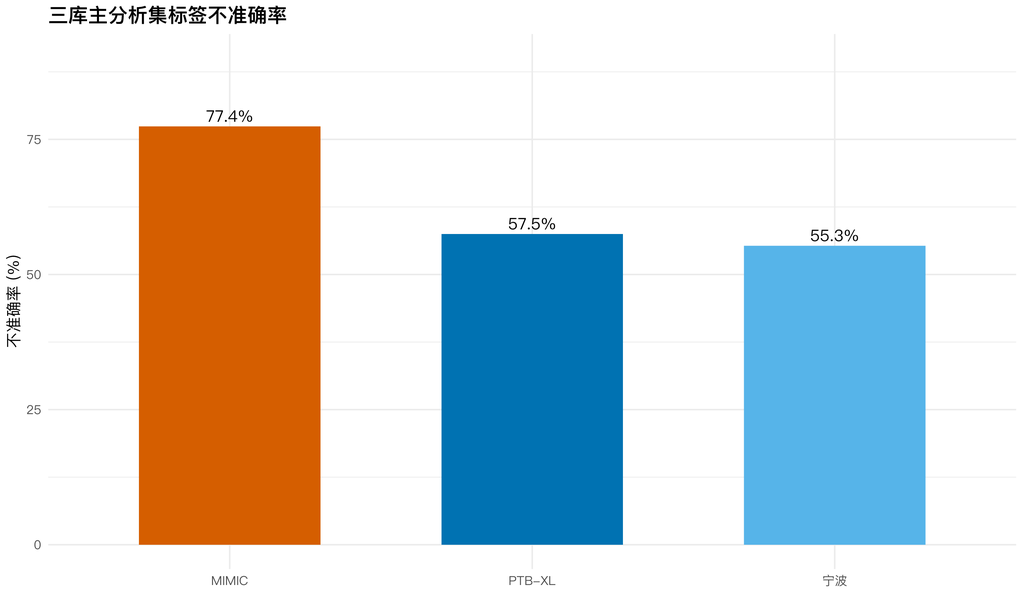

Figure 13: 图 7. 三库主分析集不准确率对照

```r
ggplot(cmp_rate, aes(x = 库, y = 不准确率, fill = 库)) +
  geom_col(width = 0.6) +
  geom_text(aes(label = sprintf("%.1f%%", 不准确率)), vjust = -0.4, size = 4, family = FONT) +
  scale_fill_manual(values = c(C_BAD, C_BLU, C_SKY)) +
  labs(title = "三库主分析集标签不准确率", x = "", y = "不准确率 (%)") +
  ylim(0, 90) + theme(legend.position = "none")
```

**展开代码**

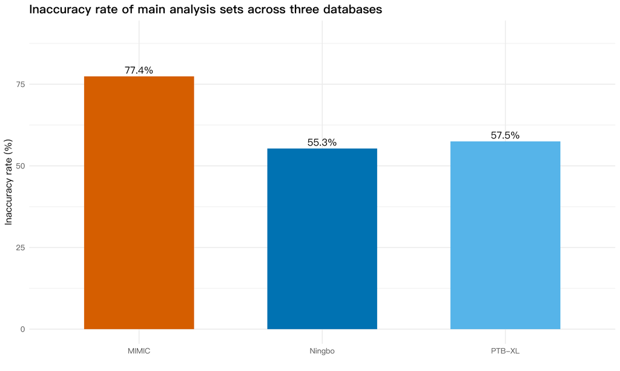

Figure 14: Figure 7. Inaccuracy rate of main analysis sets across three databases

```r
cmp_rate_en <- cmp_rate |>
  mutate(Database = recode(库, "MIMIC" = "MIMIC", "宁波" = "Ningbo", "PTB-XL" = "PTB-XL"))
ggplot(cmp_rate_en, aes(x = Database, y = 不准确率, fill = Database)) +
  geom_col(width = 0.6) +
  geom_text(aes(label = sprintf("%.1f%%", 不准确率)), vjust = -0.4, size = 4, family = FONT) +
  scale_fill_manual(values = c(C_BAD, C_BLU, C_SKY)) +
  labs(title = "Inaccuracy rate of main analysis sets across three databases", x = "", y = "Inaccuracy rate (%)") +
  ylim(0, 90) + theme(legend.position = "none")
```

## 6.2 人口学对照

**展开代码**

```r
demo_cmp |>
  gt() |> gt_std(fsize = 11) |>
  cols_label(
    库 = "数据库", 均龄 = "均龄(岁)", 中位龄 = "中位龄(岁)",
    男 = "男性", 女 = "女性", `男%` = "男性占比(%)"
  ) |>
  tab_header("表 5. 三库人口学特征对照")
```

Table 9

表 5. 三库人口学特征对照

| 数据库 | 均龄(岁) | 中位龄(岁) | 男性 | 女性 | 男性占比(%) |
| --- | --- | --- | --- | --- | --- |
| MIMIC | 57.5 | 59 | 489 | 503 | 49.3 |
| 宁波 | 60.3 | 64 | 351 | 271 | 56.4 |
| PTB-XL | 61.3 | 62 | 336 | 338 | 49.9 |

**展开代码**

```r
demo_cmp |>
  gt() |> gt_std(fsize = 11) |>
  cols_label(
    库 = "Database", 均龄 = "Mean age (yrs)", 中位龄 = "Median age (yrs)",
    男 = "Male", 女 = "Female", `男%` = "Male proportion (%)"
  ) |>
  tab_header("Table 5. Demographic characteristics across three databases")
```

Table 10

Table 5. Demographic characteristics across three databases

| Database | Mean age (yrs) | Median age (yrs) | Male | Female | Male proportion (%) |
| --- | --- | --- | --- | --- | --- |
| MIMIC | 57.5 | 59 | 489 | 503 | 49.3 |
| 宁波 | 60.3 | 64 | 351 | 271 | 56.4 |
| PTB-XL | 61.3 | 62 | 336 | 338 | 49.9 |

# 7 跨库诊断词汇对照表（含专家补充词汇）

**展开代码**

```r
vocab |>
  mutate(专家补充 = if_else(expert_supplemented == "", "—", expert_supplemented)) |>
  select(concept_zh, concept_en, ningbo, ptbxl, mimic_zh, mimic_en, 专家补充) |>
  gt() |> gt_std(fsize = 10) |>
  cols_label(
    concept_zh = "中文诊断", concept_en = "英文概念",
    ningbo = "宁波", ptbxl = "PTB-XL",
    mimic_zh = "MIMIC(中)", mimic_en = "MIMIC(英)", 专家补充 = "专家补充"
  ) |>
  tab_header("表 6. 跨库诊断标签对照词表（含专家补充词汇）")
```

Table 11

表 6. 跨库诊断标签对照词表（含专家补充词汇）

| 中文诊断 | 英文概念 | 宁波 | PTB-XL | MIMIC(中) | MIMIC(英) | 专家补充 |
| --- | --- | --- | --- | --- | --- | --- |
| 窦性心律 | Sinus rhythm | 449 | 254 | 696 | 661 | 是(中文report_cn+correctLabel) |
| 窦性心动过缓 | Sinus bradycardia | 217 | 0 | 112 | 111 | 是(中文report_cn+correctLabel) |
| 窦性心动过速 | Sinus tachycardia | 102 | 0 | 96 | 96 | 是(中文report_cn+correctLabel) |
| ST压低/T波异常 | ST depression / T abnormality | 157 | 105 | 6 | 0 | 是(中文report_cn+correctLabel) |
| 心房颤动 | Atrial fibrillation | 33 | 1 | 61 | 61 | 是(中文report_cn+correctLabel) |
| 一度房室传导阻滞 | Atrioventricular block (1st) | 23 | 36 | 46 | 43 | 是(中文report_cn+correctLabel) |
| 右束支传导阻滞 | Right bundle branch block | 10 | 44 | 54 | 28 | 是(中文report_cn+correctLabel) |
| 缺血性ST-T改变 | Myocardial ischemia | 0 | 49 | 0 | 85 | — |
| 心房扑动 | Atrial flutter | 117 | 2 | 5 | 5 | 是(中文report_cn+correctLabel) |
| 窦性心律不齐 | Sinus arrhythmia | 41 | 0 | 34 | 34 | 是(中文report_cn+correctLabel) |
| 前/前间壁心肌梗死 | Myocardial infarction (anterior) | 0 | 57 | 43 | 1 | 是(中文report_cn+correctLabel) |
| 下壁心肌梗死 | Myocardial infarction (inferior) | 0 | 34 | 54 | 2 | 是(中文report_cn+correctLabel) |
| 左前分支阻滞 | Left anterior fascicular block | 0 | 28 | 19 | 38 | 是(中文report_cn+correctLabel) |
| 心房异常/肥大 | Atrial enlargement | 3 | 8 | 22 | 48 | 是(中文report_cn+correctLabel) |
| 左束支传导阻滞 | Left bundle branch block | 0 | 12 | 32 | 31 | 是(中文report_cn+correctLabel) |
| ST段抬高 | ST elevation | 3 | 0 | 35 | 29 | 是(中文report_cn+correctLabel) |
| 心电轴偏移 | QRS axis deviation | 0 | 0 | 0 | 64 | — |
| 左室肥厚/高电压 | Left ventricular hypertrophy | 0 | 17 | 5 | 40 | 是(中文report_cn+correctLabel) |
| 室性期前收缩 | Premature ventricular complexes | 0 | 9 | 4 | 48 | 是(中文report_cn+correctLabel) |
| QT间期延长 | QT prolongation | 15 | 4 | 40 | 1 | 是(中文report_cn+correctLabel) |
| QRS低电压 | QRS low voltage | 23 | 0 | 14 | 12 | 是(中文report_cn+correctLabel) |
| 室内传导阻滞 | Intraventricular conduction delay | 0 | 17 | 17 | 4 | 是(中文report_cn+correctLabel) |
| 起搏器/起搏心律 | Pacemaker / paced rhythm | 0 | 7 | 14 | 13 | 是(中文report_cn+correctLabel) |
| 心肌损伤 | Myocardial injury | 0 | 10 | 11 | 11 | 是(中文report_cn+correctLabel) |
| 早期复极 | Early repolarization | 7 | 0 | 9 | 3 | 是(中文report_cn+correctLabel) |
| 异位房性心律 | Ectopic atrial rhythm | 0 | 0 | 6 | 10 | 是(中文report_cn+correctLabel) |
| 室上性心动过速 | Supraventricular tachycardia | 14 | 1 | 0 | 0 | — |
| 心包炎 | Pericarditis | 0 | 0 | 7 | 7 | 是(中文report_cn+correctLabel) |
| 洋地黄效应 | Digoxin effect | 0 | 9 | 0 | 0 | — |
| 二联律 | Bigeminy | 0 | 1 | 4 | 1 | 是(中文report_cn+correctLabel) |
| 房性期前收缩 | Premature atrial complexes | 0 | 0 | 5 | 0 | 是(中文report_cn+correctLabel) |
| 二/三度房室传导阻滞 | Atrioventricular block (2nd/3rd) | 5 | 0 | 0 | 0 | — |
| U波异常 | U wave abnormality | 5 | 0 | 0 | 0 | — |
| 右室肥厚 | Right ventricular hypertrophy | 0 | 1 | 1 | 2 | 是(中文report_cn+correctLabel) |
| 预激综合征 | Wolff-Parkinson-White / preexcitation | 1 | 2 | 0 | 1 | — |
| 左后分支阻滞 | Left posterior fascicular block | 0 | 3 | 0 | 0 | — |
| 电解质紊乱 | Electrolyte disturbance | 0 | 1 | 0 | 0 | — |

**展开代码**

```r
vocab |>
  mutate(专家补充 = if_else(expert_supplemented == "", "—", expert_supplemented)) |>
  select(concept_zh, concept_en, ningbo, ptbxl, mimic_zh, mimic_en, 专家补充) |>
  gt() |> gt_std(fsize = 10) |>
  cols_label(
    concept_zh = "Chinese diagnosis", concept_en = "English concept",
    ningbo = "Ningbo", ptbxl = "PTB-XL",
    mimic_zh = "MIMIC (ZH)", mimic_en = "MIMIC (EN)", 专家补充 = "Expert-added"
  ) |>
  tab_header("Table 6. Cross-database diagnosis label comparison glossary (with expert-added terms)")
```

Table 12

Table 6. Cross-database diagnosis label comparison glossary (with expert-added terms)

| Chinese diagnosis | English concept | Ningbo | PTB-XL | MIMIC (ZH) | MIMIC (EN) | Expert-added |
| --- | --- | --- | --- | --- | --- | --- |
| 窦性心律 | Sinus rhythm | 449 | 254 | 696 | 661 | 是(中文report_cn+correctLabel) |
| 窦性心动过缓 | Sinus bradycardia | 217 | 0 | 112 | 111 | 是(中文report_cn+correctLabel) |
| 窦性心动过速 | Sinus tachycardia | 102 | 0 | 96 | 96 | 是(中文report_cn+correctLabel) |
| ST压低/T波异常 | ST depression / T abnormality | 157 | 105 | 6 | 0 | 是(中文report_cn+correctLabel) |
| 心房颤动 | Atrial fibrillation | 33 | 1 | 61 | 61 | 是(中文report_cn+correctLabel) |
| 一度房室传导阻滞 | Atrioventricular block (1st) | 23 | 36 | 46 | 43 | 是(中文report_cn+correctLabel) |
| 右束支传导阻滞 | Right bundle branch block | 10 | 44 | 54 | 28 | 是(中文report_cn+correctLabel) |
| 缺血性ST-T改变 | Myocardial ischemia | 0 | 49 | 0 | 85 | — |
| 心房扑动 | Atrial flutter | 117 | 2 | 5 | 5 | 是(中文report_cn+correctLabel) |
| 窦性心律不齐 | Sinus arrhythmia | 41 | 0 | 34 | 34 | 是(中文report_cn+correctLabel) |
| 前/前间壁心肌梗死 | Myocardial infarction (anterior) | 0 | 57 | 43 | 1 | 是(中文report_cn+correctLabel) |
| 下壁心肌梗死 | Myocardial infarction (inferior) | 0 | 34 | 54 | 2 | 是(中文report_cn+correctLabel) |
| 左前分支阻滞 | Left anterior fascicular block | 0 | 28 | 19 | 38 | 是(中文report_cn+correctLabel) |
| 心房异常/肥大 | Atrial enlargement | 3 | 8 | 22 | 48 | 是(中文report_cn+correctLabel) |
| 左束支传导阻滞 | Left bundle branch block | 0 | 12 | 32 | 31 | 是(中文report_cn+correctLabel) |
| ST段抬高 | ST elevation | 3 | 0 | 35 | 29 | 是(中文report_cn+correctLabel) |
| 心电轴偏移 | QRS axis deviation | 0 | 0 | 0 | 64 | — |
| 左室肥厚/高电压 | Left ventricular hypertrophy | 0 | 17 | 5 | 40 | 是(中文report_cn+correctLabel) |
| 室性期前收缩 | Premature ventricular complexes | 0 | 9 | 4 | 48 | 是(中文report_cn+correctLabel) |
| QT间期延长 | QT prolongation | 15 | 4 | 40 | 1 | 是(中文report_cn+correctLabel) |
| QRS低电压 | QRS low voltage | 23 | 0 | 14 | 12 | 是(中文report_cn+correctLabel) |
| 室内传导阻滞 | Intraventricular conduction delay | 0 | 17 | 17 | 4 | 是(中文report_cn+correctLabel) |
| 起搏器/起搏心律 | Pacemaker / paced rhythm | 0 | 7 | 14 | 13 | 是(中文report_cn+correctLabel) |
| 心肌损伤 | Myocardial injury | 0 | 10 | 11 | 11 | 是(中文report_cn+correctLabel) |
| 早期复极 | Early repolarization | 7 | 0 | 9 | 3 | 是(中文report_cn+correctLabel) |
| 异位房性心律 | Ectopic atrial rhythm | 0 | 0 | 6 | 10 | 是(中文report_cn+correctLabel) |
| 室上性心动过速 | Supraventricular tachycardia | 14 | 1 | 0 | 0 | — |
| 心包炎 | Pericarditis | 0 | 0 | 7 | 7 | 是(中文report_cn+correctLabel) |
| 洋地黄效应 | Digoxin effect | 0 | 9 | 0 | 0 | — |
| 二联律 | Bigeminy | 0 | 1 | 4 | 1 | 是(中文report_cn+correctLabel) |
| 房性期前收缩 | Premature atrial complexes | 0 | 0 | 5 | 0 | 是(中文report_cn+correctLabel) |
| 二/三度房室传导阻滞 | Atrioventricular block (2nd/3rd) | 5 | 0 | 0 | 0 | — |
| U波异常 | U wave abnormality | 5 | 0 | 0 | 0 | — |
| 右室肥厚 | Right ventricular hypertrophy | 0 | 1 | 1 | 2 | 是(中文report_cn+correctLabel) |
| 预激综合征 | Wolff-Parkinson-White / preexcitation | 1 | 2 | 0 | 1 | — |
| 左后分支阻滞 | Left posterior fascicular block | 0 | 3 | 0 | 0 | — |
| 电解质紊乱 | Electrolyte disturbance | 0 | 1 | 0 | 0 | — |

# 8 结论与建议

1. **无记录级重复**：MIMIC 合并-8.11 经五类关键字段核查无真实重复记录，报告以全量 1000 例作为主分析集。
2. **高不准确率以遗漏型错误为主**：77.4% 标签被判定不准确，其中 38.6% 系原始标签漏报次要发现（PtfV1、T 波/ST-T 改变等），反映 MIMIC 自由文本命名空间复杂、标注粒度不一致。
3. **三库不可直接比较**：MIMIC 为 ICU 队列 + 简单随机抽样，与门诊库（宁波/PTB-XL）在人群、诊断组合、命名体系上系统性偏移；其不准确率最高不等于标签”质量最差”，而更多源于评价标准（专家补充次要发现）更细。
4. **抽样代表性有限**：简单随机抽样未分层，稀有诊断（Brugada、预激、尖端扭转等）被严重低估，错误率估计置信区间偏宽；推断门诊 ECG 总体须改用分层抽样并显式声明人群边界。
5. **专家补充词汇是跨库桥梁**：MIMIC 的中文术语与纠正标签均为专家增补，已在对照词表（表 6）中标注，建议在最终论文与模拟器中一并呈现以保证可复现与可审计。

# 9 交互式三库对照（HTML 版）

本小节为 HTML 交互组件，可在浏览器中悬停查看数值、点击按钮在「不准确率 / 准确率」间切换。Word 版见上方表 4 与图 7。

[output not shown]